# DATA 605 Week 11 Discussion

Ilya Kats

November 10, 2017

## Linear Regression Model

### First Attempt

Originally, I wanted to get creative with my data. I decided to look at NYPD data for motor vehicle collisions (available at https://data.cityofnewyork.us/Public-Safety/NYPD-Motor-Vehicle-Collisions/h9gi-nx95). My first idea was to look at how number of collisions is affected by the weather. I took daily wind and precipitation numbers from NOAA website (https://www.ncdc.noaa.gov/cdo-web/search). I only looked at the last 3 years - November 2014 through November 2017.

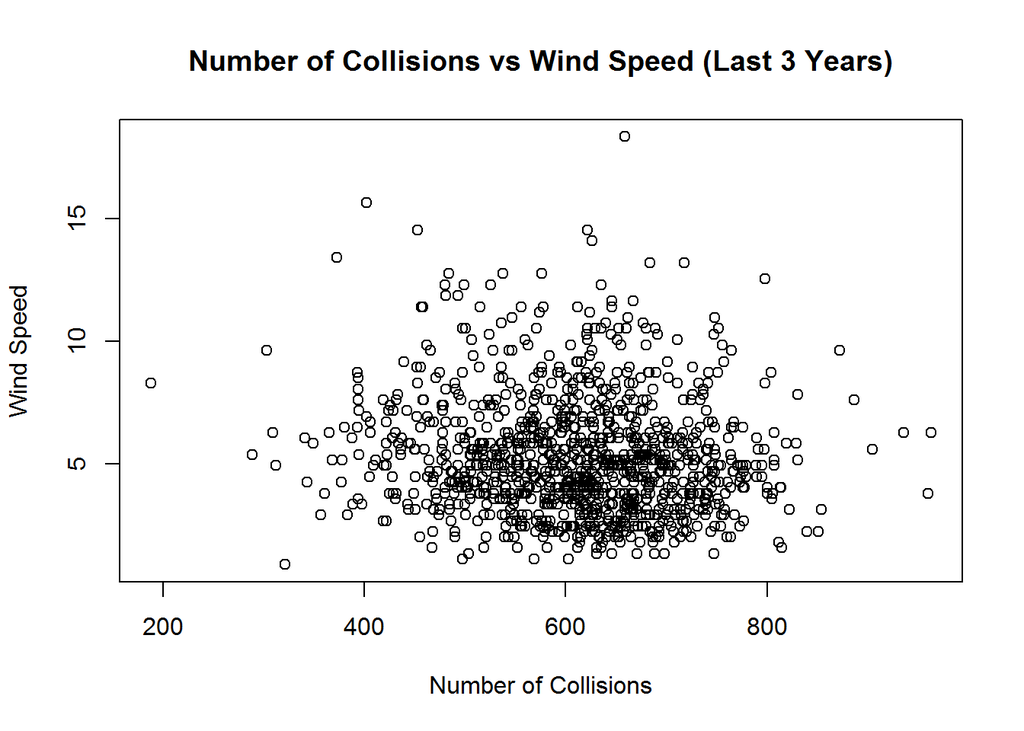

```r
weather <- read.csv('C:\\Temp\\CUNY\\1123424_2.csv')
accidents <- read.csv('C:\\Temp\\CUNY\\CollisionCount.csv')

library(tidyr)
library(dplyr)

colnames(accidents) <- c('Record','Collisions')

data <- weather %>%
  select(Record=DATE, Wind=AWND, Rain=PRCP) %>%
  inner_join(accidents, by=c('Record'))

plot(data$Wind ~ data$Collisions, xlab='Number of Collisions', ylab='Wind Speed',
     main='Number of Collisions vs Wind Speed (Last 3 Years)')
```

**Absolutely no noticeable correlation.** Same for precipitation. This was disappointing. I think it is logical to assume that there are more collisions during bad weather. The problem is that collisions vary widely - from simple fender benders to serious accidents with loss of life. Bad weather may not significantly influence daily counts, but it may influence severity.

### Second Attempt

Now is the time to go to R’s built-in datasets. I picked `airquality` - a data set containing daily air quality measurements in New York recorded from May to September 1973. My model compares `Ozone` (mean ozone in parts per billion from 1300 to 1500 hours at Roosevelt Island) with `Temp` (maximum daily temperature in degrees Fahrenheit at La Guardia Airport).

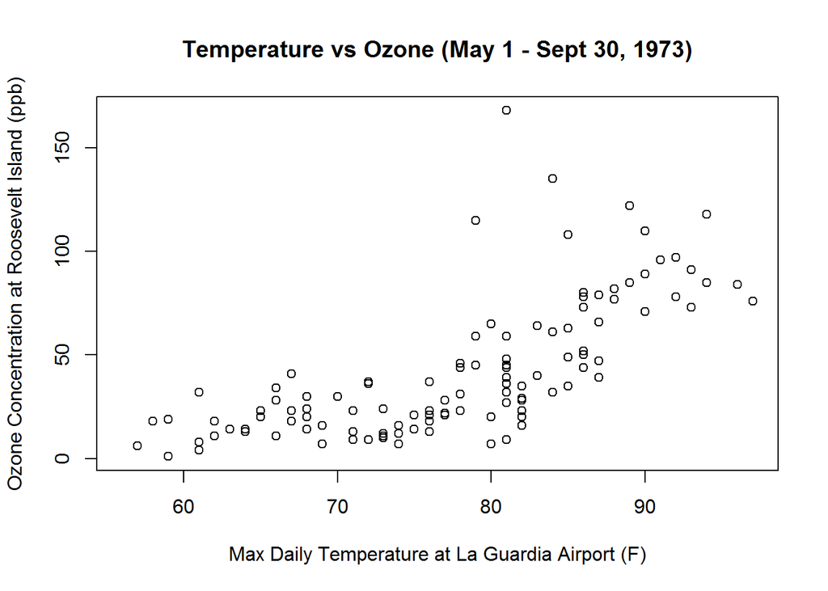

```r
plot(airquality$Temp, airquality$Ozone,
     xlab='Max Daily Temperature at La Guardia Airport (F)',
     ylab='Ozone Concentration at Roosevelt Island (ppb)',
     main='Temperature vs Ozone (May 1 - Sept 30, 1973)')
```

After a simple plot, it looks like there is some correlation.

```r
# Simple linear regression model
model <- lm(airquality$Ozone ~ airquality$Temp)
summary(model)
```

```
##
## Call:
## lm(formula = airquality$Ozone ~ airquality$Temp)
##
## Residuals:
##     Min      1Q  Median      3Q     Max
## -40.729 -17.409  -0.587  11.306 118.271
##
## Coefficients:
##                  Estimate Std. Error t value Pr(>|t|)
## (Intercept)     -146.9955    18.2872  -8.038 9.37e-13 ***
## airquality$Temp    2.4287     0.2331  10.418  < 2e-16 ***
## ---
## Signif. codes:  0 '***' 0.001 '**' 0.01 '*' 0.05 '.' 0.1 ' ' 1
##
## Residual standard error: 23.71 on 114 degrees of freedom
##   (37 observations deleted due to missingness)
## Multiple R-squared:  0.4877, Adjusted R-squared:  0.4832
## F-statistic: 108.5 on 1 and 114 DF,  p-value: < 2.2e-16
```

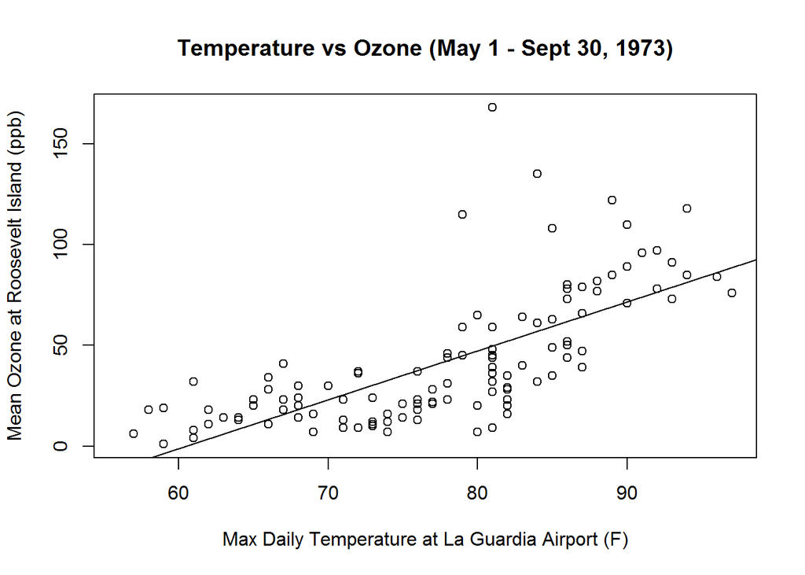

```r
# Ozone/Temp plot with regression line
plot(airquality$Ozone ~ airquality$Temp,
     xlab='Max Daily Temperature at La Guardia Airport (F)',
     ylab='Mean Ozone at Roosevelt Island (ppb)',
     main='Temperature vs Ozone (May 1 - Sept 30, 1973)')
abline(model)
```

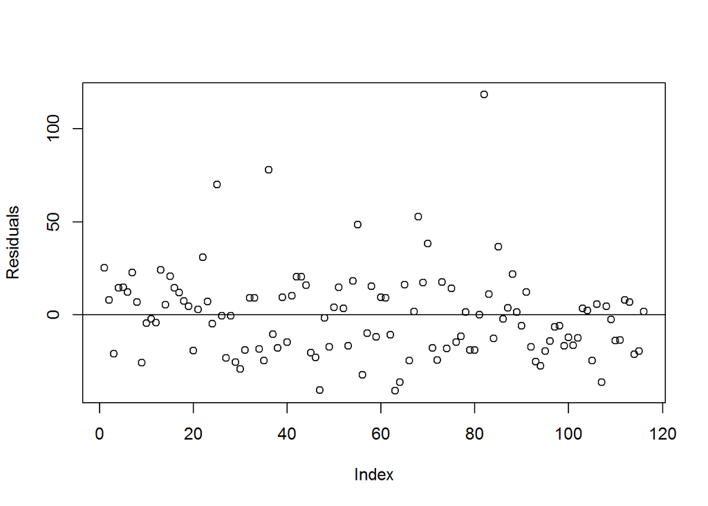

```r
# Residuals
plot(model$residuals, ylab='Residuals')
abline(a=0, b=0)
```

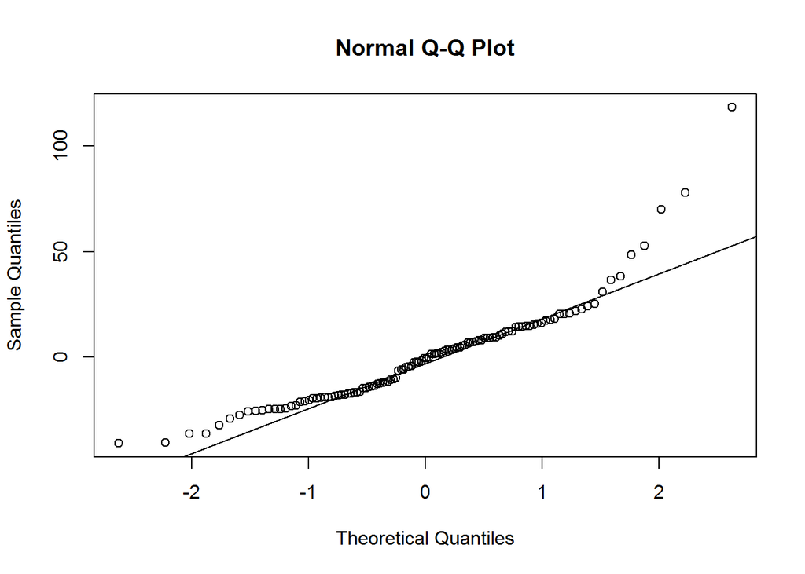

```r
# Q-Q plot
qqnorm(model$residuals)
qqline(model$residuals)
```

### Conclusion

With R-squared value at about 0.48, the model describes almost 50% of variability. Looking at residuals plot, variability is constant with no pattern. Q-Q line looks good with the exception of both tails. Temperature is statistically significant variable to predict ozone concentration at all levels. Overall I think the model fits nicely. There are a few outliers and looking at the main plot, it appears that non-linear model may fit the data better.